# HW3_DataSciMath

#### Walt Wells - 07.23-07.31.2016

### homework3.docx

1. The weights of steers in a herd are distributed normally. The variance is 40,000 and the mean steer weight is 1300 lbs. Find the probability that the weight of a randomly selected steer is greater than 979 lbs. (Round your answer to 4 decimal places)

```r
sd <- sqrt(40000)
mean <- 1300
round(pnorm(979, mean, sd, lower.tail = FALSE), 4)
```

```
[1] 0.9458
```

2. SVGA monitors manufactured by TSI Electronics have life spans that have a normal distribution with a variance of 1,960,000 and a mean life span of 11,000 hours. If a SVGA monitor is selected at random, find the probability that the life span of the monitor will be more than 8340 hours. (Round your answer to 4 decimal places)

```r
sd <- sqrt(1960000)
mean <- 11000
round(pnorm(8340, mean, sd, lower.tail = FALSE), 4)
```

```
[1] 0.9713
```

3. Suppose the mean income of firms in the industry for a year is 80 million dollars with a standard deviation of 3 million dollars. If incomes for the industry are distributed normally, what is the probability that a randomly selected firm will earn between 83 and 85 million dollars? (Round your answer to 4 decimal places)

```r
sd <- 3
mean <- 80
round(pnorm(85, mean, sd) - pnorm(83, mean, sd), 4)
```

```
[1] 0.1109
```

4. Suppose GRE Verbal scores are normally distributed with a mean of 456 and a standard deviation of 123. A university plans to offer tutoring jobs to students whose scores are in the top 14%. What is the minimum score required for the job offer? Round your answer to the nearest whole number, if necessary.

```r
mean <- 456
sd <- 123
round(qnorm(.86, mean, sd), 0)
```

```
[1] 589
```

5. The lengths of nails produced in a factory are normally distributed with a mean of 6.13 centimeters and a standard deviation of 0.06 centimeters. Find the two lengths that separate the top 7% and the bottom 7%. These lengths could serve as limits used to identify which nails should be rejected. Round your answer to the nearest hundredth, if necessary.

```r
mean <- 6.13
sd <- 0.06
round(qnorm(.93, mean, sd), 2)
```

```
[1] 6.22
```

```r
round(qnorm(.07, mean, sd), 2)
```

```
[1] 6.04
```

6. An English professor assigns letter grades on a test according to the following scheme.
- A: Top 13% of scores
- B: Scores below the top 13% and above the bottom 55%
- C: Scores below the top 45% and above the bottom 20%
- D: Scores below the top 80% and above the bottom 9%
- F: Bottom 9% of scores

Scores on the test are normally distributed with a mean of 78.8 and a standard deviation of 9.8. Find the numerical limits for a C grade. Round your answers to the nearest whole number, if necessary.

```r
mean <- 78.8
sd <- 9.8
round(qnorm(.55, mean, sd))
```

```
[1] 80
```

```r
round(qnorm(.20, mean, sd))
```

```
[1] 71
```

7. Suppose ACT Composite scores are normally distributed with a mean of 21.2 and a standard deviation of 5.4. A university plans to admit students whose scores are in the top 45%. What is the minimum score required for admission? Round your answer to the nearest tenth, if necessary.

```r
mean <- 21.2
sd <- 5.4
round(qnorm(.55, mean, sd), 1)
```

```
[1] 21.9
```

8. Consider the probability that less than 11 out of 151 students will not graduate on time. Assume the probability that a given student will not graduate on time is 9%. Approximate the probability using the normal distribution. (Round your answer to 4 decimal places.)

```r
round(pbinom(10, 151, .09), 4)
```

```
[1] 0.192
```

9. The mean lifetime of a tire is 48 months with a standard deviation of 7. If 147 tires are sampled, what is the probability that the mean of the sample would be greater than 48.83 months? (Round your answer to 4 decimal places)

```r
#define function to get standard error of the mean
getsem <- function(sd, n) {
    return(sd/sqrt(n))
}

popmean <- 48
sd <- 7
n <- 147
sem <- getsem(sd, n)
round(pnorm(48.83, popmean, sem, lower.tail = FALSE), 4)
```

```
[1] 0.0753
```

10. The quality control manager at a computer manufacturing company believes that the mean life of a computer is 91 months, with a standard deviation of 10. If he is correct, what is the probability that the mean of a sample of 68 computers would be greater than 93.54 months? (Round your answer to 4 decimal places)

```r
# Standardize
popmean <- 91
sd <- 10
n <- 68
sem <- getsem(sd, n)
round(pnorm(93.54, popmean, sem, lower.tail=FALSE), 4)
```

```
[1] 0.0181
```

11. A director of reservations believes that 7% of the ticketed passengers are no-shows. If the director is right, what is the probability that the proportion of no-shows in a sample of 540 ticketed passengers would differ from the population proportion by less than 3%? (Round your answer to 4 decimal places)

```r
pearsonZ <- function(r) {
    return(.5*(log((1+r)/(1-r))))
}
pearsonSEM <- function(n) {
    return(1/sqrt(n-3))
}
# find area between 4% and 10%
mean <- pearsonZ(.07)
sem <- pearsonSEM(540)
p4 <- pnorm(pearsonZ(.04), mean, sem)
p10 <- pnorm(pearsonZ(.10), mean, sem)
round(p10 - p4, 4)
```

```
[1] 0.5153
```

12. A bottle maker believes that 23% of his bottles are defective. If the bottle maker is accurate, what is the probability that the proportion of defective bottles in a sample of 602 bottles would differ from the population proportion by greater than 4%? (Round your answer to 4 decimal places)

```r
mean <- pearsonZ(.23)
sem <- pearsonSEM(602)
# find area < 19% and area > 27%
p19 <- pnorm(pearsonZ(.19), mean, sem)
p27 <- pnorm(pearsonZ(.27), mean, sem, lower.tail=FALSE)
round(p19 + p27, 4)
```

```
[1] 0.301
```

13. A research company desires to know the mean consumption of beef per week among males over age 48. Suppose a sample of size 208 is drawn with x̅ = 3.9. Assume sigma = 0.8 . Construct the 80% confidence interval for the mean number of lb. of beef per week among males over 48. (Round your answers to 1 decimal place)

```r
sampmean <- 3.9
sd <- 0.8
n <- 208
t <- abs(qt(.2/2, n-1)) #2 sided
se <- sd/sqrt(n)

lower <- round(sampmean - t*se, 1)
upper <- round(sampmean + t*se, 1)
lower; upper
```

```
[1] 3.8
```

```
[1] 4
```

14. An economist wants to estimate the mean per capita income (in thousands of dollars) in a major city in California. Suppose a sample of size 7472 is drawn with x̅ = 16.6. Assume sigma = 11 . Construct the 98% confidence interval for the mean per capita income. (Round your answers to 1 decimal place)

```r
sampmean <- 16.6
sd <- 11
n <- 7472
t<- abs(qt(.02/2, n-1)) #2 sided
se <- sd/sqrt(n)

lower <- round(sampmean - t*se, 1)
upper <- round(sampmean + t*se, 1)
lower; upper
```

```
[1] 16.3
```

```
[1] 16.9
```

15. Find the value of t such that 0.05 of the area under the curve is to the left of t. Assume the degrees of freedom equals 26.
- Step 1. Choose the picture which best describes the problem.
- Step 2. Write your answer below.

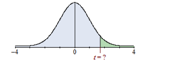

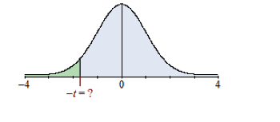

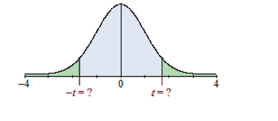

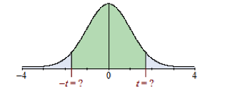

```r
t <- abs(qt(.05, 26-1)) #1 sided
# the top right image (or dist2.png) shows .05 of the area under the curve to the left of -t.
round(t, 4)
```

```
[1] 1.7081
```

16. The following measurements ( in picocuries per liter ) were recorded by a set of helium gas detectors installed in a laboratory facility:

```r
# 383.6, 347.1, 371.9, 347.6, 325.8, 337
```

Using these measurements, construct a 90% confidence interval for the mean level of helium gas present in the facility. Assume the population is normally distributed.